# week11_in_class

## week 11

Write code that opens a text file quiz.txt for reading and prints the first line of this text file.

```python
f=open("grocery.txt","r")
print(f.readline())
f.close()
```

```
Apples
```

```python
f=open("grocery.txt","r")
lines=f.readlines()
f.close()

lines[0]
```

```
'Apples\n'
```

```python
f=open("grocery.txt","r")
text=f.read()
f.close()
```

```python
text
```

```
'Apples\neggs\nmilk\nSupreme pizza\nchips'
```

```python
k=text.find("\n")
text[:k]
```

```
'Apples'
```

```python
text.split("\n")[0]
```

```
'Apples'
```

(1) Write the code that takes the string `mystr` separates every word in the list `mylist`. You can assume that all of the words in `mystr` are separated only by the space character.

(2) Write the code that given `mylist` from question 1, puts it back together in the original string

```python
mystr="Which method is the most efficient"
```

```python
mylist=mystr.split(" ")
print(mylist)
```

```
['Which', 'method', 'is', 'the', 'most', 'efficient']
```

```python
" ".join(mylist)
```

```
'Which method is the most efficient'
```

(5) Write code that opens a text file quiz.txt for reading, reads all the lines and puts them in a list, and then join the lines in a string on the character ’&&’

(6) Write code that opens a text file quiz.txt for writing and appends the word ’potato’ at the end of the file

```python
f=open("grocery.txt","r")
lines=f.readlines()
f.close()

lines
```

```
['Apples\n', 'eggs\n', 'milk\n', 'Supreme pizza\n', 'chips']
```

```python
"&&".join(lines)
```

```
'Apples\n&&eggs\n&&milk\n&&Supreme pizza\n&&chips'
```

```python
f=open("grocery.txt","a")
f.write("\npotato")
f.close()
```

```python
with open("grocery.txt","a") as f:
    f.write("\noranges")
```

Write the code to replace each a and e in mystr with their upper case version.

```python
mystr=mystr.replace('a',"A")
mystr=mystr.replace("e","E")
```

```python
mystr
```

```
'Which mEthod is thE most EfficiEnt'
```

```python
r = 'oi'

for letter in r:
    mystr=mystr.replace(letter,letter.upper())
mystr
```

```
'WhIch mEthOd Is thE mOst EffIcIEnt'
```

```python
r = 'OI'
k = 'oi'

for i in range(2):
    mystr=mystr.replace(r[i],k[i])
mystr
```

```
'Which mEthod is thE most EfficiEnt'
```

```python
import requests

url="https://scassani.github.io/MTH337-S2021/_downloads/74af82a6b009f7e6692546a8bc09cbda/gulliver.txt"
verne = requests.get(url).text
```

```python
skip = ".,;:()_-\"?!<>$&*#\n\r[]\{\}"
```

**Ex.** clean the book (replace all of these symbols with a space character). Replace the `'` with nothing

```python
for char in skip:
    verne=verne.replace(char," ")

verne=verne.replace("'","")
```

```python
len(verne)
```

```
278417
```

```python
verne.split(" ")
```

```
['GULLIVERS',
 'TRAVELS',
 '',
 '',
 '',
 'Into',
 'Several',
 'Remote',
 'Regions',
 'of',
 'the',
 'World',
 '',
 '',
 '',
 'by',
 '',
 '',
 '',
 'JONATHAN',
 'SWIFT',
 '',
 'D',
 'D',
 '',
 '',
 '',
 '',
 'Edited',
 'with',
 'Introduction',
 'and',
 'Notes',
 'by',
 'Thomas',
 'M',
 '',
 'Balliet',
 '',
 'Superintendent',
```

[output cut: 946 more lines]

```
 'him',
 'of',
 'high',
 'treason',
 '',
 '',
 'makes',
 'his',
 'escape',
 'to',
 'Blefuscu',
 '',
 'His',
 'reception',
 ...]
```

Note: to count the words you will need:

1. remove the `''` characters
2. handle capitalized letters

```python
verne.split()
```

```
['GULLIVERS',
 'TRAVELS',
 'Into',
 'Several',
 'Remote',
 'Regions',
 'of',
 'the',
 'World',
 'by',
 'JONATHAN',
 'SWIFT',
 'D',
 'D',
 'Edited',
 'with',
 'Introduction',
 'and',
 'Notes',
 'by',
 'Thomas',
 'M',
 'Balliet',
 'Superintendent',
 'of',
 'Schools',
 'Springfield',
 'Mass',
 'With',
 'Thirty',
 'Eight',
 'Illustrations',
 'and',
 'a',
 'Map',
 'PART',
 'I',
 'A',
 'VOYAGE',
 'TO',
```

[output cut: 946 more lines]

```
 'to',
 'the',
 'Author',
 'The',
 'execution',
 'of',
 'a',
 'criminal',
 'The',
 'Author',
 'shows',
 'his',
 'skill',
 'in',
 ...]
```

```python
import numpy as np
```

```python
numbers=np.random.randint(0,10,100000)

count={}

for num in numbers:
    if num in count:
        count[num]+=1
    else:
        count[num]=1
```

```python
print(count)
```

```
{6: 10022, 4: 9964, 7: 10101, 5: 9824, 8: 9831, 3: 10117, 9: 10075, 0: 10075, 1: 9989, 2: 10002}
```

```python
numbers[:50]
```

```
array([6, 3, 2, 9, 7, 2, 5, 4, 9, 7, 1, 5, 0, 1, 7, 0, 3, 2, 9, 6, 4, 5,
       8, 1, 5, 0, 7, 1, 7, 9, 9, 5, 6, 2, 4, 6, 5, 7, 3, 7, 9, 3, 4, 1,
       1, 1, 8, 5, 5, 1])
```

```python
count[6]
```

```
10022
```

## `sorted`

```python
mylist=['howdy','Hello','Hi','good morning']
sorted(mylist)
```

```
['Hello', 'Hi', 'good morning', 'howdy']
```

```python
mylist
```

```
['howdy', 'Hello', 'Hi', 'good morning']
```

```python
myl=sorted(mylist)
```

```python
myl
```

```
['Hello', 'Hi', 'good morning', 'howdy']
```

```python
sorted(mylist,reverse=True)
```

```
['howdy', 'good morning', 'Hi', 'Hello']
```

```python
print(count)
```

```
{6: 10022, 4: 9964, 7: 10101, 5: 9824, 8: 9831, 3: 10117, 9: 10075, 0: 10075, 1: 9989, 2: 10002}
```

```python
print(sorted(count.items()))
```

```
[(0, 10075), (1, 9989), (2, 10002), (3, 10117), (4, 9964), (5, 9824), (6, 10022), (7, 10101), (8, 9831), (9, 10075)]
```

```python
print(count.items())
```

```
dict_items([(6, 10022), (4, 9964), (7, 10101), (5, 9824), (8, 9831), (3, 10117), (9, 10075), (0, 10075), (1, 9989), (2, 10002)])
```

```python
grades =[ [4,7,10], [5,2,2], [6,7,8], [10,2,0] ]
sorted(grades,reverse=True)
```

```
[[10, 2, 0], [6, 7, 8], [5, 2, 2], [4, 7, 10]]
```

```python
def avg(mylist):
    return sum(mylist)/len(mylist)
```

```python
sorted(grades,key=avg,reverse=True)
```

```
[[4, 7, 10], [6, 7, 8], [10, 2, 0], [5, 2, 2]]
```

```python
sorted(grades,key=np.mean,reverse=True)
```

```
[[4, 7, 10], [6, 7, 8], [10, 2, 0], [5, 2, 2]]
```

**ex** sort the students based on their quiz 3 grade

```python
def quiz3(mylist):
    return mylist[2]
```

```python
sorted(grades,key=quiz3,reverse=True)
```

```
[[4, 7, 10], [6, 7, 8], [5, 2, 2], [10, 2, 0]]
```

## bar plot

```python
country=["China","USA","Italy","Brazil"]
pop = [1398,328,60,211]
```

```python
import matplotlib.pyplot as plt
```

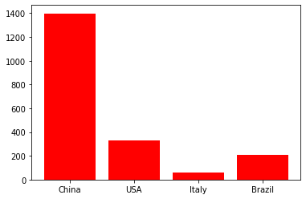

```python
plt.bar(country,pop,color="r");
```

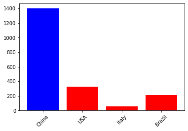

```python
x=plt.bar(country,pop,color="r")
x[0].set_color("b")
plt.xticks(rotation=45)
plt.show()
```

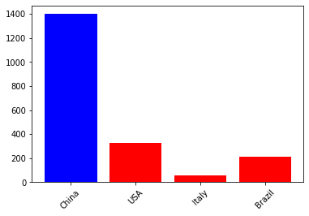

```python
x=plt.bar(range(4),pop,color="r",tick_label=country)
x[0].set_color("b")
plt.xticks(rotation=45)
plt.show()
```

```python
x=np.linspace(1,10,1000)
y1=2*x
y2=np.exp(-x)
y3=np.log(x)
y4=x**2
y5=1/x

def logplot(x,y,t=""):


    plt.figure(figsize=(12,6))
    plt.subplot(141)
    plt.plot(x,y)
    plt.title("x ; y")
    plt.subplot(142)
    plt.plot(np.log(x),y)
    plt.title("log-x ; y")
    plt.subplot(143)
    plt.plot(x,np.log(y))
    plt.title("x ; log-y")
    plt.subplot(144)
    plt.plot(np.log(x),np.log(y))
    plt.title("log-x ; log-y")

    plt.suptitle(t)

    return None
```

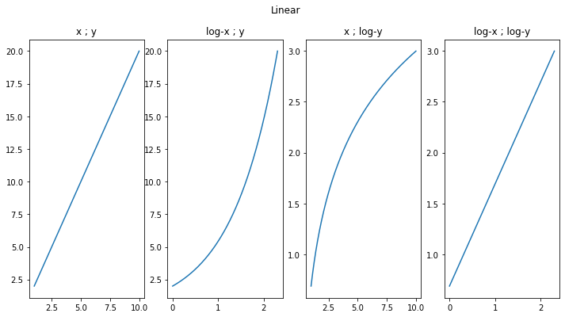

```python
logplot(x,y1,"Linear")
```

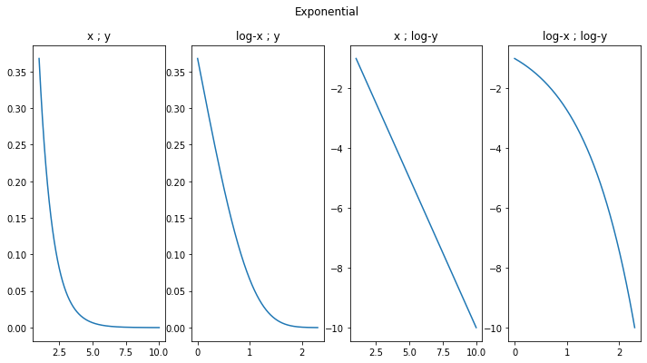

```python
logplot(x,y2,t="Exponential")
```

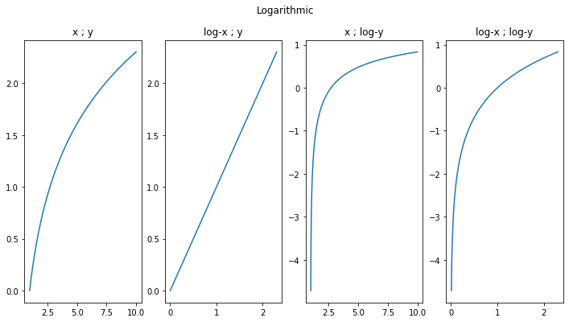

```python
logplot(x,y3,'Logarithmic')
```

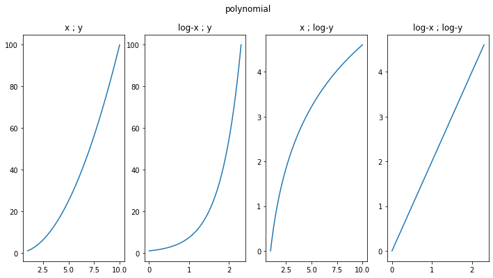

```python
logplot(x,y4,'polynomial')
```

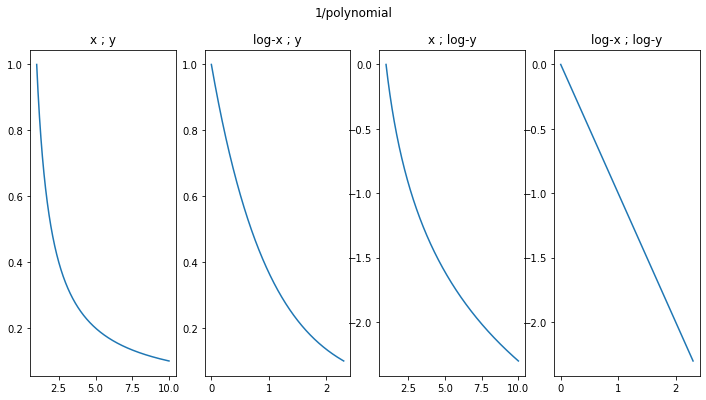

```python
logplot(x,y5,'1/polynomial')
```

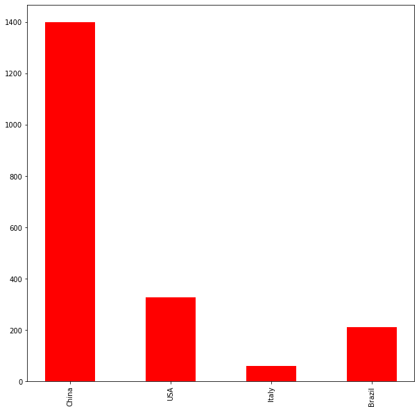

```python
country=["China","USA","Italy","Brazil"]
pop = [1398,328,60,211]
plt.figure(figsize=(10,10))
plt.bar(country,pop,color="r",width=0.5)
plt.xticks(rotation=90)
plt.show()
```